# EDA_Project_Gapminder

Pushkar

February 11, 2019

## Objective

The purpose of this page is to perform exploratory data analysis on the Gapminder data. In this assignment, I have performed data transformation and manipulation tasks using basic functions of dplyr package.  
Links to github:  
.rmd -> https://github.com/pushkardps/dataanalytics/blob/master/eda_gapminder/Code/EDA_Gapminder.Rmd  
.html -> https://github.com/pushkardps/dataanalytics/blob/master/eda_gapminder/Portfolio/EDA_Gapminder.html  
rpubs -> http://rpubs.com/pushkardps/468894

## Setting up the questions

This is an important part of the data analysis cycle. Here’s what I want know from the dataset:  
- Top ten countries by popuation, life expectancy, income - Which country boasts of the highest life expectancy?  
- How has the per capita income increased over the years for India?  
- How does per capita vary across regions?  
- How does life expectancy vary with per capita income?

## Packages required

Below is a list of the packages I have used to perform data analysis

```r
library(readr) # used to import dataset
library(dplyr) # used to perform data transformation and manipulation
library(ggplot2) # used for data visualization
```

## Data Description

**Source** : https://raw.githubusercontent.com/birdsarah/pydata-nc/master/tutorial/assets/gapminder.csv  
**Attributes** :  
Country: tells us which country the data belongs to  
Year: the year for which the data corresponds to  
Life: life expectancy in the corresponding year for a country  
Income: per capita income  
Region: region to which the country belongs to

```r
# import data
gap <- data.frame(read_csv("C:/Users/pushk/Desktop/pb/Harrisburg University/Exploratory Data Analysis/Git/dataanalytics/eda_gapminder/Data/gapminder.csv"))
```

### Dimensions

```r
# number of rows and columns
dim(gap)
```

```
## [1] 41284     6
```

### Column Names

```r
# names of columns
names(gap)
```

```
## [1] "Country"    "Year"       "life"       "population" "income"
## [6] "region"
```

### Top & bottom values

```r
#Checking top and bottom values
head(gap)
```

```
##       Country Year     life population income     region
## 1 Afghanistan 1800 28.21100    3280000    603 South Asia
## 2 Afghanistan 1801 28.20075         NA    603 South Asia
## 3 Afghanistan 1802 28.19051         NA    603 South Asia
## 4 Afghanistan 1803 28.18026         NA    603 South Asia
## 5 Afghanistan 1804 28.17001         NA    603 South Asia
## 6 Afghanistan 1805 28.15977         NA    603 South Asia
```

```r
tail(gap)
```

```
##       Country Year  life population income                region
## 41279   Åland 1992 80.83      24834     NA Europe & Central Asia
## 41280   Åland 1993 81.80      24950     NA Europe & Central Asia
## 41281   Åland 1994 80.63      25066     NA Europe & Central Asia
## 41282   Åland 1995 79.88      25183     NA Europe & Central Asia
## 41283   Åland 1996 80.00      25301     NA Europe & Central Asia
## 41284   Åland 1997 80.10      25419     NA Europe & Central Asia
```

There are 41284 rows and 6 columns. The six columns are named Country, Year, life, population, income and region. Looking at a few top and bottom rows, it appears that there are a few NA values in population and income columns

### Data types

```r
# observe data types of the dataset
str(gap)
```

```
## 'data.frame':    41284 obs. of  6 variables:
##  $ Country   : chr  "Afghanistan" "Afghanistan" "Afghanistan" "Afghanistan" ...
##  $ Year      : int  1800 1801 1802 1803 1804 1805 1806 1807 1808 1809 ...
##  $ life      : num  28.2 28.2 28.2 28.2 28.2 ...
##  $ population: num  3280000 NA NA NA NA NA NA NA NA NA ...
##  $ income    : num  603 603 603 603 603 603 603 603 603 603 ...
##  $ region    : chr  "South Asia" "South Asia" "South Asia" "South Asia" ...
```

### Countries & Regions

```r
# number of countries in the dataset
countries <- unique(gap$Country)
length(countries)
```

```
## [1] 197
```

```r
# number of regions in the dataset
unique(gap$region)
```

```
## [1] "South Asia"                 "Europe & Central Asia"
## [3] "Middle East & North Africa" "Sub-Saharan Africa"
## [5] "America"                    "East Asia & Pacific"
```

```r
length(unique(gap$region))
```

```
## [1] 6
```

The data spans across 197 countries and 6 regions

### Summary

```r
# basic summary statistics for the dataset
summary(gap)
```

```
##    Country               Year           life         population
##  Length:41284       Min.   :1800   Min.   : 1.00   Min.   :1.548e+03
##  Class :character   1st Qu.:1854   1st Qu.:31.00   1st Qu.:5.335e+05
##  Mode  :character   Median :1908   Median :35.12   Median :3.358e+06
##                     Mean   :1907   Mean   :42.88   Mean   :2.119e+07
##                     3rd Qu.:1962   3rd Qu.:55.60   3rd Qu.:1.078e+07
##                     Max.   :2015   Max.   :84.10   Max.   :1.376e+09
##                                                    NA's   :25817
##      income          region
##  Min.   :   142   Length:41284
##  1st Qu.:   883   Class :character
##  Median :  1450   Mode  :character
##  Mean   :  4571
##  3rd Qu.:  3483
##  Max.   :182668
##  NA's   :2341
```

It appears that there are some NAs in the population column, likely due to census data not being avaialable on a per year basis. The data spans from year 1800 to as recent as 2015. It looks like the lowest per capita income is 142 while the max per capita income 182,668; it is difficult to judge this because there are NA’s in the income column as well.

## Exploratory Data Analysis

```r
#standardize variables
gap2 <- gap
names(gap2) <- c("country", "year", "lifeExpectancy", "population", "perCapIncome", "region")
```

```r
#filter the dataset for year of 2015
gap2015 <- gap2 %>% filter( year == 2015)
```

### A1. What are the top/ bottom 10 countries by life expectancy, population and per capita income in 2015?

#### Top ten countries

##### By income

```r
head(
  gap2015  %>%
  select(country, region, perCapIncome) %>%
  arrange(desc(perCapIncome)) , 10)
```

```
##                 country                     region perCapIncome
## 1                 Qatar Middle East & North Africa       132877
## 2            Luxembourg      Europe & Central Asia        88314
## 3                Kuwait Middle East & North Africa        82633
## 4             Singapore        East Asia & Pacific        80794
## 5                Brunei        East Asia & Pacific        73003
## 6                Norway      Europe & Central Asia        64304
## 7  United Arab Emirates Middle East & North Africa        60749
## 8           Switzerland      Europe & Central Asia        56118
## 9         United States                    America        53354
## 10         Saudi Arabia Middle East & North Africa        52469
```

##### By life expectancy

```r
head(
  gap2015  %>%
  select(country, region, lifeExpectancy) %>%
  arrange(desc(lifeExpectancy)) , 10)
```

```
##        country                     region lifeExpectancy
## 1      Andorra      Europe & Central Asia           84.1
## 2        Japan        East Asia & Pacific           83.5
## 3  Switzerland      Europe & Central Asia           82.9
## 4      Iceland      Europe & Central Asia           82.8
## 5       Cyprus      Europe & Central Asia           82.6
## 6       Israel Middle East & North Africa           82.4
## 7        Italy      Europe & Central Asia           82.1
## 8        Malta      Europe & Central Asia           82.1
## 9    Singapore        East Asia & Pacific           82.1
## 10       Qatar Middle East & North Africa           82.0
```

##### By population

```r
head(
  gap2015  %>%
  select(country, region, population) %>%
  arrange(desc(population)) , 10)
```

```
##          country                region population
## 1          China   East Asia & Pacific 1376048943
## 2          India            South Asia 1311050527
## 3  United States               America  321773631
## 4      Indonesia   East Asia & Pacific  257563815
## 5         Brazil               America  207847528
## 6       Pakistan            South Asia  188924874
## 7        Nigeria    Sub-Saharan Africa  182201962
## 8     Bangladesh            South Asia  160995642
## 9         Russia Europe & Central Asia  143456918
## 10        Mexico               America  127017224
```

#### Bottom ten countries

##### By income

```r
head(
  gap2015  %>%
  select(country, region, perCapIncome) %>%
  arrange((perCapIncome)) , 10)
```

```
##             country             region perCapIncome
## 1           Somalia Sub-Saharan Africa          624
## 2           Burundi Sub-Saharan Africa          777
## 3            Malawi Sub-Saharan Africa          799
## 4  Congo, Dem. Rep. Sub-Saharan Africa          809
## 5             Niger Sub-Saharan Africa          943
## 6           Liberia Sub-Saharan Africa          958
## 7           Eritrea Sub-Saharan Africa         1129
## 8        Mozambique Sub-Saharan Africa         1176
## 9            Guinea Sub-Saharan Africa         1225
## 10    Guinea-Bissau Sub-Saharan Africa         1386
```

##### By life expectancy

```r
head(
  gap2015  %>%
  select(country, region, lifeExpectancy) %>%
  arrange((lifeExpectancy)) , 10)
```

```
##             country             region lifeExpectancy
## 1           Lesotho Sub-Saharan Africa          48.50
## 2         Swaziland Sub-Saharan Africa          51.50
## 3     Guinea-Bissau Sub-Saharan Africa          53.40
## 4        Mozambique Sub-Saharan Africa          56.40
## 5              Mali Sub-Saharan Africa          57.60
## 6       Afghanistan         South Asia          57.63
## 7              Chad Sub-Saharan Africa          57.70
## 8       South Sudan Sub-Saharan Africa          58.00
## 9  Congo, Dem. Rep. Sub-Saharan Africa          58.30
## 10     Sierra Leone Sub-Saharan Africa          58.50
```

##### By population

```r
head(
  gap2015  %>%
  select(country, region, population) %>%
  arrange((population)) , 10)
```

```
##                  country                region population
## 1       Marshall Islands   East Asia & Pacific      52993
## 2                Andorra Europe & Central Asia      70473
## 3               Dominica               America      72680
## 4    Antigua and Barbuda               America      91818
## 5             Seychelles    Sub-Saharan Africa      96471
## 6  Micronesia, Fed. Sts.   East Asia & Pacific     104460
## 7                  Tonga   East Asia & Pacific     106170
## 8                Grenada               America     106825
## 9               Kiribati   East Asia & Pacific     112423
## 10 Sao Tome and Principe    Sub-Saharan Africa     190344
```

For the year 2015, **Qatar has the highest per capita income at $132877**, followed by Luxembourg at $88314 and Kuwait at $82633. **Andorra** , Japan and Switzerland have the **highest life expectancies** at **84.1 years** , 83.5 and 82.9 respectively. **China** is the **most populated country** with a population of **1,376,048,943** followed by India 1,311,050,527 followd by United States with only 321,773,631.

### A2. Plot per capita income of India over the years

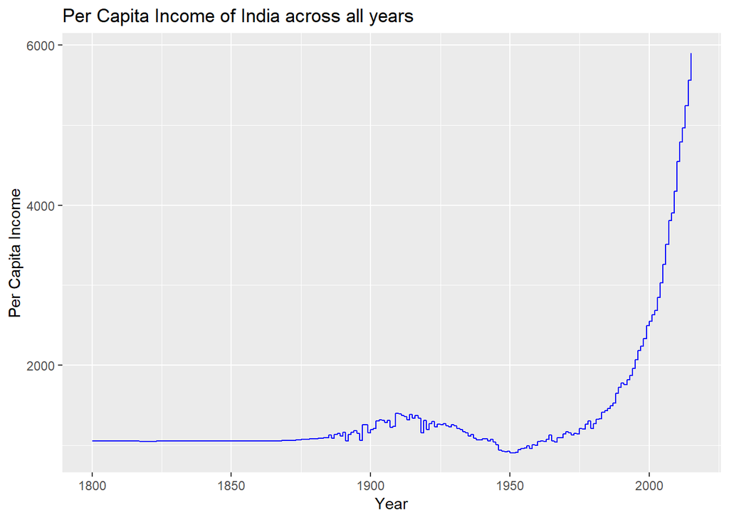

```r
pciIndia <-gap2 %>% filter(country=="India") %>%
            ggplot() +
            geom_step(mapping = aes(x = year,y=perCapIncome),linetype=1,color='blue') +
            ggtitle("Per Capita Income of India across all years") +
            labs(y="Per Capita Income", x="Year")
pciIndia
```

It looks the per capita income fell from the early 1900s right till 1950, per capita income seems to have increased from 1950s with steep increases from 1990’s to current.

### A3. Compare per capita income across regions

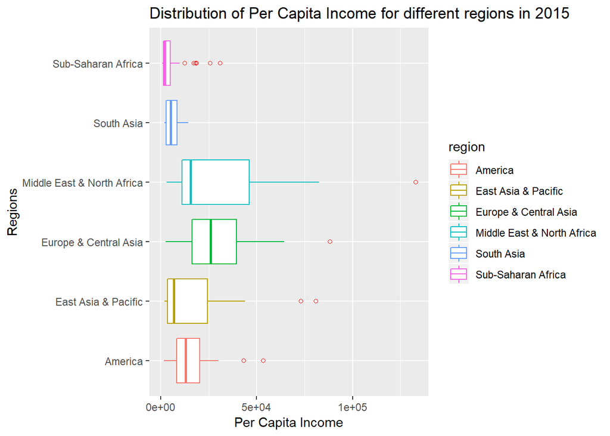

```r
pciRegions <- gap2015 %>% arrange(perCapIncome) %>%
              ggplot(data = gap2015,mapping = aes(x = region,y=perCapIncome,color = region)) +
              geom_boxplot(outlier.colour = "red", outlier.shape = 1) +
              coord_flip() +
              ggtitle("Distribution of Per Capita Income for different regions in 2015") +
              labs(y="Per Capita Income", x="Regions")
pciRegions
```

The box-plot shows that developed regions like Europe & Central Asia have larger per capita income compared to lesser developed regions like Sub-Saharan Africa or South Asia. It is surprising to see America region comparable to Middle East & North Africa but that is due to a lot of less developed countries present in the America region.

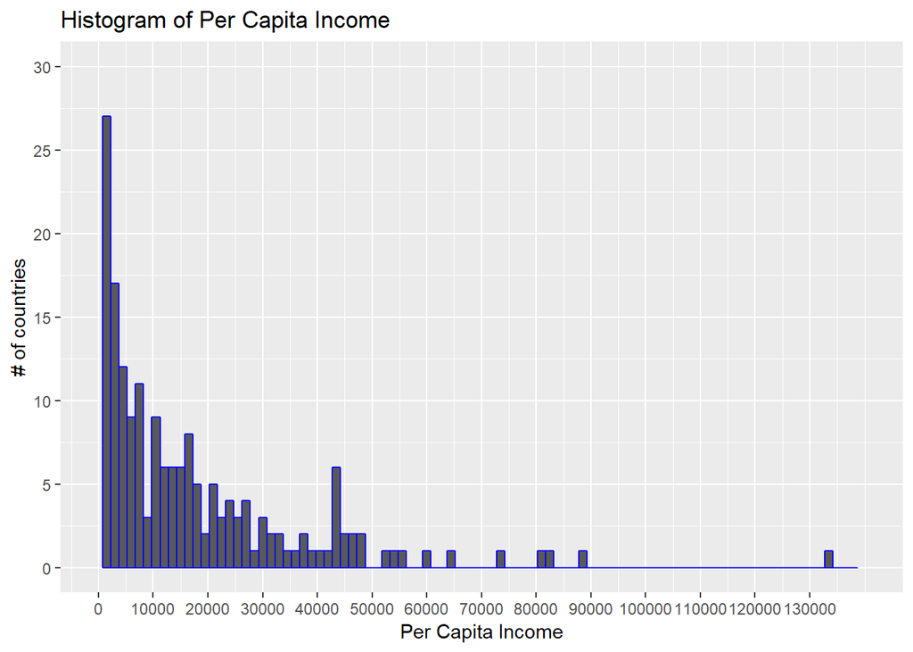

```r
  options(scipen=10000) #to ensure x axis shows like normal in the graph

  gap2015 %>%
  ggplot() +
  geom_histogram(mapping = aes(x = (perCapIncome)), binwidth = 1500, color = "blue") +
  ggtitle("Histogram of Per Capita Income") +
  labs(x="Per Capita Income", y="# of countries")  +
  scale_x_continuous(breaks = seq(0,135000,10000), limits = c(0,140000)) +
  scale_y_continuous(breaks = seq(0,35,5), limits = c(0,30))
```

```r
below30k <- 100 * nrow(filter(gap2015, perCapIncome < 30000)) / nrow(gap2015)
below30k
```

```
## [1] 80.33708
```

```r
above50K <- nrow(filter(gap2015, perCapIncome > 50000))
above50K
```

```
## [1] 10
```

```r
above130 <- filter(gap2015, perCapIncome >130000)
above130
```

```
##   country year lifeExpectancy population perCapIncome
## 1   Qatar 2015             82    2235355       132877
##                       region
## 1 Middle East & North Africa
```

### A5. How does life expectancy vary with per capita income?

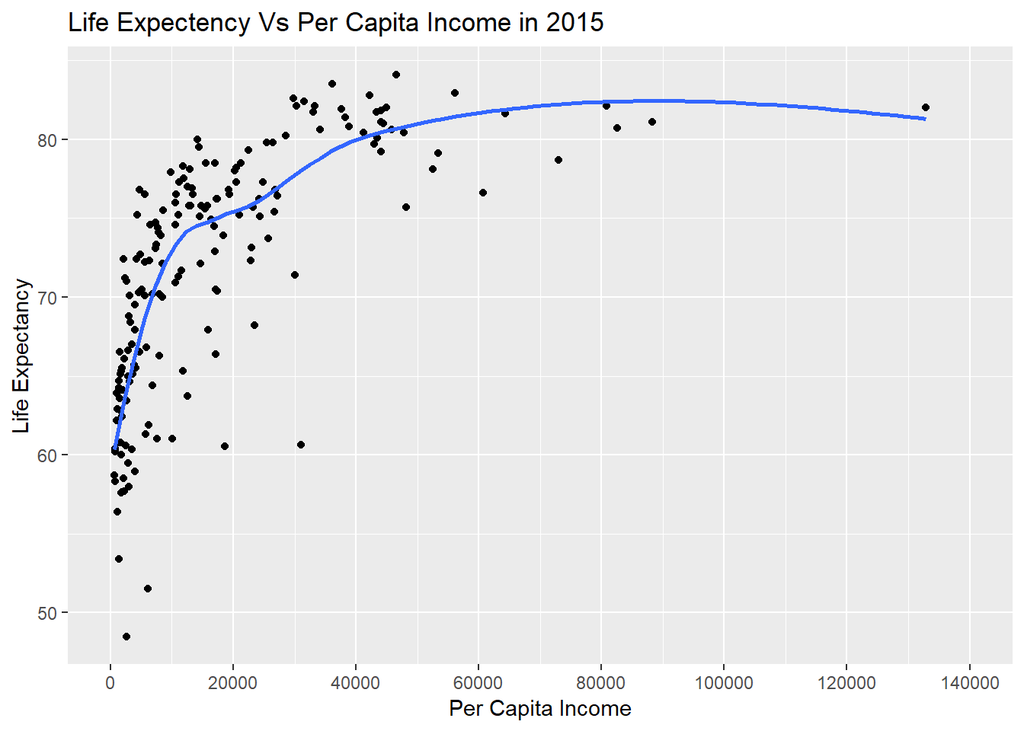

```r
options(scipen=10000)

bb <-gap2015 %>% ggplot(aes(x = perCapIncome, y = lifeExpectancy)) + geom_point() + geom_smooth(se=F) + ggtitle("Life Expectency Vs Per Capita Income in 2015") + labs(x="Per Capita Income", y="Life Expectancy")

bb + scale_x_continuous(breaks = seq(0,140000,20000), limits = c(0,140000))
```

From the graph, it looks like life expectancy mproves with increase in per capita income but this has to be taken with a grain of salt because of the outlier and certain higher income countries. If we look closely then some countries with per capita income below $10000 whose life expectancies are comparable to countries with per capita income above $10000. Also there are countries with income between $40000 and $60000 who have higher life expectancies than countries with greater than $60000 of income.

I am curious to if this pattern remains the same across regions. Lets have a look.

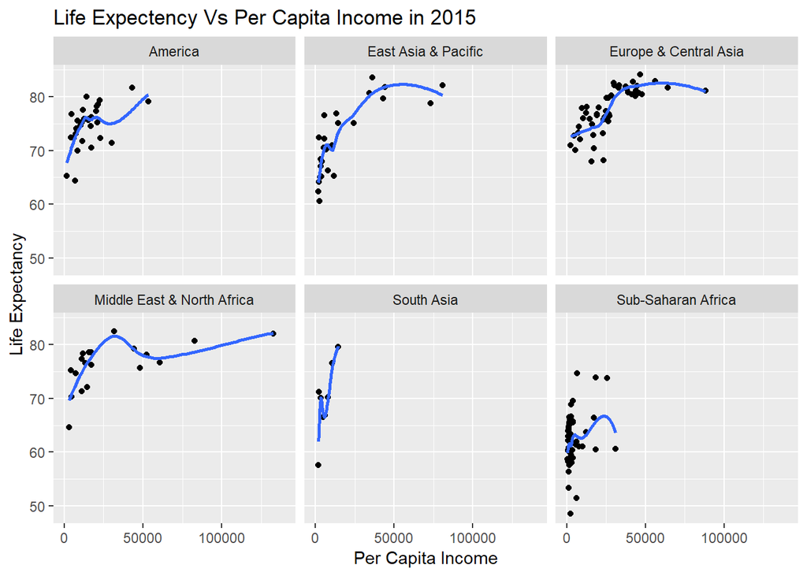

```r
bb <-gap2015 %>% ggplot(aes(x = perCapIncome, y = lifeExpectancy)) +facet_wrap(~ region)+
 geom_point() + geom_smooth(se=F) + ggtitle("Life Expectency Vs Per Capita Income in 2015") + labs(x="Per Capita Income", y="Life Expectancy")

bb + scale_x_continuous(breaks = seq(0,100000,50000), limits = c(0,140000))
```

Its interesting to see that the pattern looks similar in East Asia and Europe and Central Asia but looks a bit different for America and Middle East most likely due to extremes found the underlying data. The curve looks steep in South Asia, that might be due to less number of samples in the South Asia segment. The pattern does not make any sense in Sub-Saharan Africa region.

### A6. How does life expectancy vary with population and per capita income?

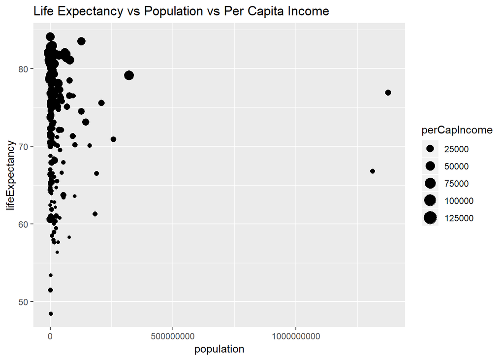

```r
gap2015 %>% ggplot(aes(x=population, y=lifeExpectancy, size=perCapIncome)) + geom_point() +
  ggtitle("Life Expectancy vs Population vs Per Capita Income")
```

Looks like I will need to readjust the scale. Color coding by regions might also give us a beter idea of the graph we are looking at.

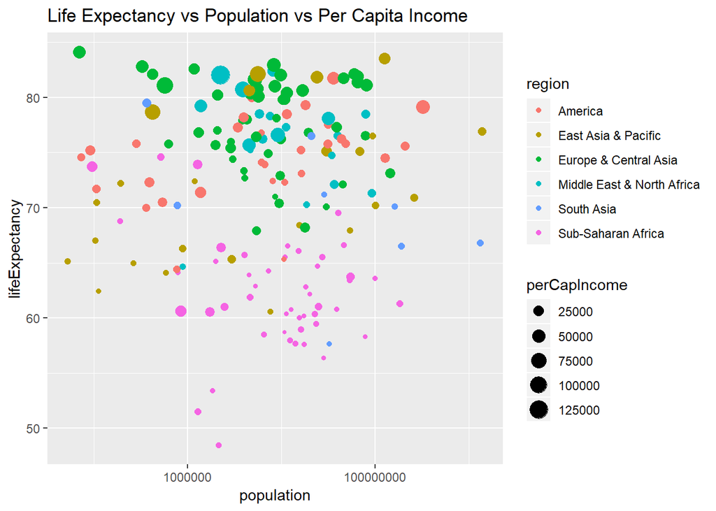

```r
gap2015 %>% ggplot(aes(x=population, y=lifeExpectancy, size=perCapIncome, color = region)) + geom_point()  + scale_x_log10() + ggtitle("Life Expectancy vs Population vs Per Capita Income")
```

Let us also try to split graphs by regions

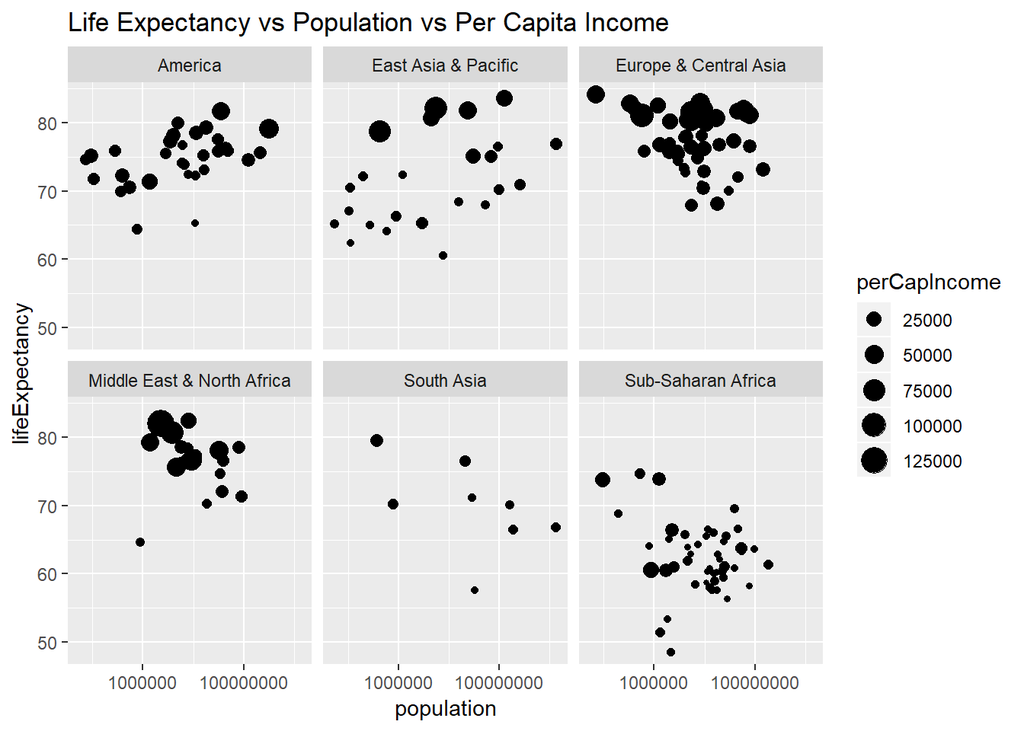

```r
gap2015 %>% ggplot(aes(x=population, y=lifeExpectancy, size=perCapIncome)) + facet_wrap(~region) + geom_point()  + scale_x_log10() + ggtitle("Life Expectancy vs Population vs Per Capita Income")
```

It looks like Middle East & North Africa region have the least amount of variability when it comes to population while East Asia & Pacific has the most variability. Its interesting to note that most of the Europe & Central Asia countries have higher per capita income and life expectancy than that of other regions. There are some countries in Europe & Central Asia who have high per capita income despite population being less than 1000000. Its even more surprising to see similar examples in Sub-Saharan Africa.